# Exploratory Data Analysis (EDA)

**ANSWER**

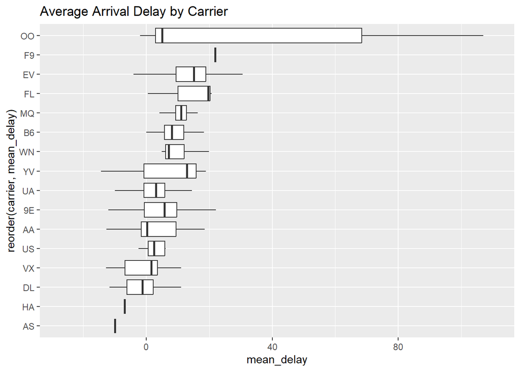

```r
library(nycflights13)
library(dplyr)


flights_not_cancelled = flights %>% # Filter out cancelled flights
  filter(!is.na(arr_delay))


grouped_flights =flights_not_cancelled %>% # Group flights by carrier and dest
  group_by(carrier, dest)

# Calculate the average arrival delay for each carrier and dest pair.
average_arrival_delay = grouped_flights %>%
summarise(mean_delay = mean(arr_delay))
## `summarise()` has grouped output by 'carrier'. You can override using the
## `.groups` argument.

# make side-by-side boxplots to compare
library(ggplot2)
ggplot(average_arrival_delay, aes(x = reorder(carrier, mean_delay), y = mean_delay)) +
  geom_boxplot(outlier.shape = NA) +
  coord_flip() +
  ggtitle("Average Arrival Delay by Carrier")
```

*Question* Which carrier had the least delays? Which carrier had the worst delays?

*Answer* From box plot, we can see the distribution of flight delays of different carriers averaged over destinations. Based on median delay value, the carrier with the least delays (best carrier) is “AS” and the carrier with the worst delays is “F9”. But one can notice that there is no variability in their box-plots. This may be due to the effect that these carriers flew to only one destination. For example it could be case that one carrier flew to a destination where the weather is always clear, therefore does not face delay. We need to take care of this effect in our analysis*

*ii) Small sample bias*

*Question* Is there a small `n` problem in your data analysis?

*ANSWER* Yes, there is a `n’ problem in our data analysis. As we outlined in previous question, some carriers flew to only one destination, therefore may behave differently from others. We count the number of destinations per carrier to answer this. We used the following block of code for this answer.

```r
flights_non_cancelled = filter(flights, !is.na(arr_delay))
dest_per_carrier = flights_non_cancelled %>%
  group_by(carrier, dest) %>%
  summarize(count = n()) %>%
  group_by(carrier) %>%
  summarize(destinations = n())
## `summarise()` has grouped output by 'carrier'. You can override using the
## `.groups` argument.
dest_per_carrier
## # A tibble: 16 × 2
##    carrier destinations
##    <chr>          <int>
##  1 9E                48
##  2 AA                19
##  3 AS                 1
##  4 B6                42
##  5 DL                40
##  6 EV                61
##  7 F9                 1
##  8 FL                 3
##  9 HA                 1
## 10 MQ                20
## 11 OO                 5
## 12 UA                47
## 13 US                 5
## 14 VX                 5
## 15 WN                11
## 16 YV                 3
```

*iii) Deleting outliers and reconsidering the problem**

We remove the carriers that only flew to one destination. Re-draw your boxplot and re-name the best/worst carriers.

```r
flights_multiple_dest=flights_not_cancelled[flights_not_cancelled$carrier!="F9", ]  #removing F9 carrier
flights_multiple_dest=flights_multiple_dest[flights_multiple_dest$carrier!="HA", ]  #removing HA carrier
flights_multiple_dest=flights_multiple_dest[flights_multiple_dest$carrier!="AS", ]  #removing AS carrier
unique(flights_multiple_dest$carrier)        #just making sure that we have deleted the F9, HA, ASA carriers
```

```
##  [1] "UA" "AA" "B6" "DL" "EV" "MQ" "US" "WN" "VX" "FL" "9E" "YV" "OO"
```

```r
#now since we have removed singe destination carriers, we can repeat part i)
grouped_flights =flights_multiple_dest %>%    # Group flights by carrier and dest
  group_by(carrier, dest)

# Calculate the average arrival delay for each carrier and dest pair.
average_arrival_delay = grouped_flights %>%
summarise(mean_delay = mean(arr_delay))
```

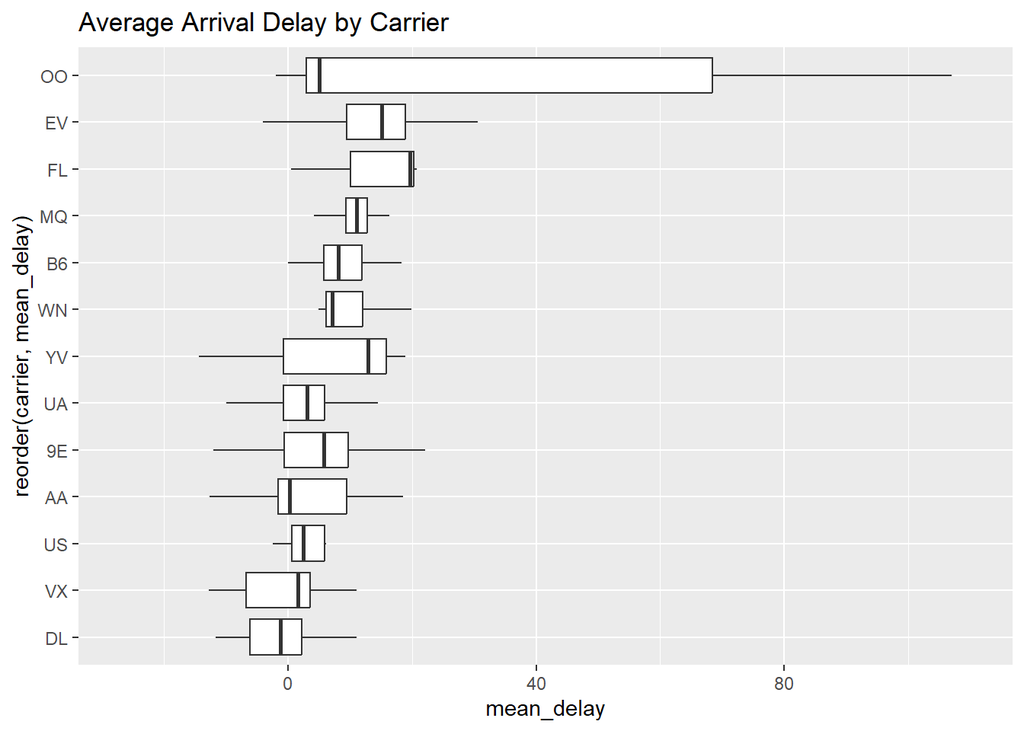

```r
# make side-by-side boxplots to compare
library(ggplot2)
ggplot(average_arrival_delay, aes(x = reorder(carrier, mean_delay), y = mean_delay)) +
  geom_boxplot(outlier.shape = NA) +
  coord_flip() +
  ggtitle("Average Arrival Delay by Carrier")
```